# EX_MINERIADATOSII_PREPROCESADO_EJ1

Patricia López Sanz

2023-08-28

# EJERCICIO 1:

Clasificación con redes Bayesianas y otros modelos de minería de datos.

Con el propósito de estudiar las causas del abandono de los clientes de un banco se proporciona un conjunto de datos con 12 variables de 4.986 clientes. Cada cliente tiene los siguientes atributos:

Variables de la base de datos:

• Customer ID: la identificación única de cada cliente individual. • Credit Score: un número que representa la solvencia del cliente. • Country: el país desde el que el cliente realiza operaciones bancarias. • Gender: el género con el que se identifica el cliente. • Age: Representa la edad de los clientes. • Tenure: Indica cuántos años ha estado el cliente con el banco. • Balance: La cantidad actualmente disponible en la cuenta del cliente. • Products Number: el número de productos comprados por el cliente a través del banco. • Credit Card: nos dice si el cliente tiene una tarjeta de crédito. • Active Member: indica si el cliente es un miembro activo o inactivo. • Estimated Salary: estimación por parte del banco de los ingresos del cliente. • Churn: indicador de si el cliente se ha ido o no del banco. Esta variable se usa como etiqueta de clase.

El objetivo general de esta prueba de evaluación consiste en analizar a los clientes bancarios. Para ello, se testarán diferentes métodos y algoritmos y se deberá seleccionar aquel o aquellos métodos que sean más óptimos de cara a predecir la intención de abandonar el banco. Entre los modelos es necesario incluir obligatoriamente los resultados de las redes bayesianas explicadas en el módulo minería de datos II.

## 1. LIBRERÍAS A UTILIZAR:

```r
# Limpieza del entorno

rm(list = ls())
options(warn = -1)

# Carga de librerías

suppressPackageStartupMessages({

  library(sampling)
  library(lubridate)
  library(fastDummies)
  library(funModeling)
  library(skimr)
  library(foreign)
  library(tidyverse)
  library(corrplot)
  library(patchwork)
  library(arulesCBA)
  library(missRanger)
  library(openxlsx)
  library(kableExtra)
  library(dplyr)
  library(inspectdf)
  library(gmodels)
  library(descr)
  library(solitude)
  library(dlookr)
  library(conflicted)
  library(flextable)
  library(formattable)

})

# Resolución de conflictos por funciones similares en paquetes diferentes

conflict_prefer('select', 'dplyr')
```

```
## [conflicted] Will prefer dplyr::select over any other package.
```

```r
conflict_prefer('summarize', 'dplyr')
```

```
## [conflicted] Will prefer dplyr::summarize over any other package.
```

```r
conflict_prefer('filter', 'dplyr')
```

```
## [conflicted] Will prefer dplyr::filter over any other package.
```

```r
conflict_prefer('rename', 'dplyr')
```

```
## [conflicted] Will prefer dplyr::rename over any other package.
```

```r
conflict_prefer('mutate', 'dplyr')
```

```
## [conflicted] Will prefer dplyr::mutate over any other package.
```

```r
conflict_prefer('recode', 'dplyr')
```

```
## [conflicted] Will prefer dplyr::recode over any other package.
```

```r
conflict_prefer('rbind', 'base')
```

```
## [conflicted] Will prefer base::rbind over any other package.
```

```r
conflict_prefer('cbind', 'base')
```

```
## [conflicted] Will prefer base::cbind over any other package.
```

```r
conflict_prefer('varImp', 'caret')
```

```
## [conflicted] Will prefer caret::varImp over any other package.
```

```r
conflict_prefer('unique', 'base')
```

```
## [conflicted] Will prefer base::unique over any other package.
```

```r
conflict_prefer("rescale", "scales")
```

```
## [conflicted] Will prefer scales::rescale over any other package.
```

```r
conflict_prefer("freq", "funModeling")
```

```
## [conflicted] Will prefer funModeling::freq over any other package.
```

```r
conflict_prefer("CrossTable", "gmodels")
```

```
## [conflicted] Will prefer gmodels::CrossTable over any other package.
```

## 2. LECTURA Y PREPARACIÓN DE LOS DATOS:

```r
datos<-read.csv("C:\\Users\\soho_\\Desktop\\DATOS_3erTRIMESTRE\\M8_MINERÍADATOS2\\EX_PRÁCTICO_MINERIADATOS2_2023\\datos_examen_clasificacion_redes_bayesianas.csv", stringsAsFactors = TRUE)
```

- Comenzamos observando la estructura de nuestro dataframe:

```r
str(datos)
```

```
## 'data.frame':    4986 obs. of  12 variables:
##  $ customer_id     : int  15647311 15737888 15574012 15656148 15737173 15600882 15643966 15737452 15788218 15661507 ...
##  $ credit_score    : int  608 850 645 376 497 635 616 653 549 587 ...
##  $ country         : Factor w/ 2 levels "Germany","Spain": 2 2 2 1 2 2 1 1 2 2 ...
##  $ gender          : Factor w/ 2 levels "Female","Male": 1 1 2 1 2 1 2 2 1 2 ...
##  $ age             : int  41 43 44 29 24 35 45 58 24 45 ...
##  $ tenure          : int  1 2 8 4 3 7 3 1 9 6 ...
##  $ balance         : num  83808 125511 113756 115047 0 ...
##  $ products_number : int  1 1 2 4 2 2 2 1 2 1 ...
##  $ credit_card     : int  0 1 1 1 1 1 0 1 1 0 ...
##  $ active_member   : int  1 1 0 0 0 1 1 0 1 0 ...
##  $ estimated_salary: num  112543 79084 149757 119347 76390 ...
##  $ churn           : int  0 0 1 1 0 0 0 1 0 0 ...
```

- Para nuestro estudio la variable CUSTOMER_ID no es relevante, así que la omitiremos de la base de datos:

```r
datos<-datos[,-1]
```

- Recodificamos como factores las variables que han sido grabadas como números y que son variables categóricas:

```r
datos$credit_card<-as.factor(datos$credit_card)
levels(datos$credit_card) <- c("No", "Si")
datos$active_member<-as.factor(datos$active_member)
levels(datos$active_member) <- c("No", "Si")
datos$churn<-as.factor(datos$churn)
levels(datos$churn) <- c("No", "Si")
```

- Vemos la nueva estructura de los datos con los cambios que hemos hecho:

```r
str(datos)
```

```
## 'data.frame':    4986 obs. of  11 variables:
##  $ credit_score    : int  608 850 645 376 497 635 616 653 549 587 ...
##  $ country         : Factor w/ 2 levels "Germany","Spain": 2 2 2 1 2 2 1 1 2 2 ...
##  $ gender          : Factor w/ 2 levels "Female","Male": 1 1 2 1 2 1 2 2 1 2 ...
##  $ age             : int  41 43 44 29 24 35 45 58 24 45 ...
##  $ tenure          : int  1 2 8 4 3 7 3 1 9 6 ...
##  $ balance         : num  83808 125511 113756 115047 0 ...
##  $ products_number : int  1 1 2 4 2 2 2 1 2 1 ...
##  $ credit_card     : Factor w/ 2 levels "No","Si": 1 2 2 2 2 2 1 2 2 1 ...
##  $ active_member   : Factor w/ 2 levels "No","Si": 2 2 1 1 1 2 2 1 2 1 ...
##  $ estimated_salary: num  112543 79084 149757 119347 76390 ...
##  $ churn           : Factor w/ 2 levels "No","Si": 1 1 2 2 1 1 1 2 1 1 ...
```

## 3. ANÁLISIS DESCRIPTIVO DE LOS DATOS:

- Empezamos con el análisis estadístico de los datos:

```r
summary(datos) %>%
  kable() %>%
  kable_styling(bootstrap_options = 'striped', font_size = 12, full_width = F) %>%
  scroll_box(width = "100%")
```

|  | credit_score | country | gender | age | tenure | balance | products_number | credit_card | active_member | estimated_salary | churn |
| --- | --- | --- | --- | --- | --- | --- | --- | --- | --- | --- | --- |
|  | Min. :350.0 | Germany:2509 | Female:2282 | Min. :18.00 | Min. : 0.000 | Min. : 0 | Min. :1.000 | No:1474 | No:2426 | Min. : 11.58 | No:3759 |
|  | 1st Qu.:586.0 | Spain :2477 | Male :2704 | 1st Qu.:32.00 | 1st Qu.: 3.000 | 1st Qu.: 54181 | 1st Qu.:1.000 | Si:3512 | Si:2560 | 1st Qu.: 50704.05 | Si:1227 |
|  | Median :651.0 | NA | NA | Median :38.00 | Median : 5.000 | Median :108328 | Median :1.000 | NA | NA | Median :100862.45 | NA |
|  | Mean :651.4 | NA | NA | Mean :39.33 | Mean : 5.021 | Mean : 90960 | Mean :1.529 | NA | NA | Mean :100282.37 | NA |
|  | 3rd Qu.:718.0 | NA | NA | 3rd Qu.:45.00 | 3rd Qu.: 8.000 | 3rd Qu.:131586 | 3rd Qu.:2.000 | NA | NA | 3rd Qu.:149447.96 | NA |
|  | Max. :850.0 | NA | NA | Max. :88.00 | Max. :10.000 | Max. :250898 | Max. :4.000 | NA | NA | Max. :199992.48 | NA |

- Vemos el balance de la variable clase que estamos estudiando:

```r
table(datos$churn) %>%
  kable() %>%
  kable_styling(bootstrap_options = 'striped', font_size = 12, full_width = F) %>%
  scroll_box(width = "100%")
```

| Var1 | Freq |
| --- | --- |
| No | 3759 |
| Si | 1227 |

Vemos que de los 4986 clientes, 1227 abandonaron el banco y ya no son clientes.

- Comprobamos que no hay registros repetidos:

```r
anyDuplicated(datos)
```

```
## [1] 0
```

- Utilizamos el comando skim que nos presenta algo más de información, como un histograma de cada variable numérica y el comando df-status que nos muestra el número de ceros de cada variable:

```r
skim(datos) %>%
  kable() %>%
  kable_styling(bootstrap_options = 'striped', font_size = 12, full_width = F) %>%
  scroll_box(width = "100%")
```

| skim_type | skim_variable | n_missing | complete_rate | factor.ordered | factor.n_unique | factor.top_counts | numeric.mean | numeric.sd | numeric.p0 | numeric.p25 | numeric.p50 | numeric.p75 | numeric.p100 | numeric.hist |
| --- | --- | --- | --- | --- | --- | --- | --- | --- | --- | --- | --- | --- | --- | --- |
| factor | country | 0 | 1 | FALSE | 2 | Ger: 2509, Spa: 2477 | NA | NA | NA | NA | NA | NA | NA | NA |
| factor | gender | 0 | 1 | FALSE | 2 | Mal: 2704, Fem: 2282 | NA | NA | NA | NA | NA | NA | NA | NA |
| factor | credit_card | 0 | 1 | FALSE | 2 | Si: 3512, No: 1474 | NA | NA | NA | NA | NA | NA | NA | NA |
| factor | active_member | 0 | 1 | FALSE | 2 | Si: 2560, No: 2426 | NA | NA | NA | NA | NA | NA | NA | NA |
| factor | churn | 0 | 1 | FALSE | 2 | No: 3759, Si: 1227 | NA | NA | NA | NA | NA | NA | NA | NA |
| numeric | credit_score | 0 | 1 | NA | NA | NA | 6.513941e+02 | 96.288348 | 350.00 | 586.00 | 651.0 | 718.0 | 850.0 | ▁▃▇▇▃ |
| numeric | age | 0 | 1 | NA | NA | NA | 3.933414e+01 | 10.491123 | 18.00 | 32.00 | 38.0 | 45.0 | 88.0 | ▃▇▂▁▁ |
| numeric | tenure | 0 | 1 | NA | NA | NA | 5.021059e+00 | 2.896156 | 0.00 | 3.00 | 5.0 | 8.0 | 10.0 | ▇▆▆▇▅ |
| numeric | balance | 0 | 1 | NA | NA | NA | 9.095997e+04 | 57056.054008 | 0.00 | 54180.73 | 108328.4 | 131586.4 | 250898.1 | ▅▃▇▂▁ |
| numeric | products_number | 0 | 1 | NA | NA | NA | 1.529483e+00 | 0.592864 | 1.00 | 1.00 | 1.0 | 2.0 | 4.0 | ▇▇▁▁▁ |
| numeric | estimated_salary | 0 | 1 | NA | NA | NA | 1.002824e+05 | 57690.256966 | 11.58 | 50704.05 | 100862.4 | 149448.0 | 199992.5 | ▇▇▇▇▇ |

```r
df_status(datos)
```

```
##            variable q_zeros p_zeros q_na p_na q_inf p_inf    type unique
## 1      credit_score       0    0.00    0    0     0     0 integer    443
## 2           country       0    0.00    0    0     0     0  factor      2
## 3            gender       0    0.00    0    0     0     0  factor      2
## 4               age       0    0.00    0    0     0     0 integer     67
## 5            tenure     208    4.17    0    0     0     0 integer     11
## 6           balance    1199   24.05    0    0     0     0 numeric   3786
## 7   products_number       0    0.00    0    0     0     0 integer      4
## 8       credit_card       0    0.00    0    0     0     0  factor      2
## 9     active_member       0    0.00    0    0     0     0  factor      2
## 10 estimated_salary       0    0.00    0    0     0     0 numeric   4986
## 11            churn       0    0.00    0    0     0     0  factor      2
```

- LLama la atención la variable BALANCE por el número alto de CEROS que tiene. Parece indicar que casi 1200 clientes no disponían de saldo en cuenta.
- Y la variable TENURE que también tiene CEROS, parece indicar que unos 200 clientes llevan menos de 1 año como clientes del banco.
- Aunque vemos en los análisis anteriores que no hay datos ausentes, lo comprobamos de nuevo con los siguientes comandos:

```r
sapply(datos, function(x) sum(is.na(x)))
```

```
##     credit_score          country           gender              age
##                0                0                0                0
##           tenure          balance  products_number      credit_card
##                0                0                0                0
##    active_member estimated_salary            churn
##                0                0                0
```

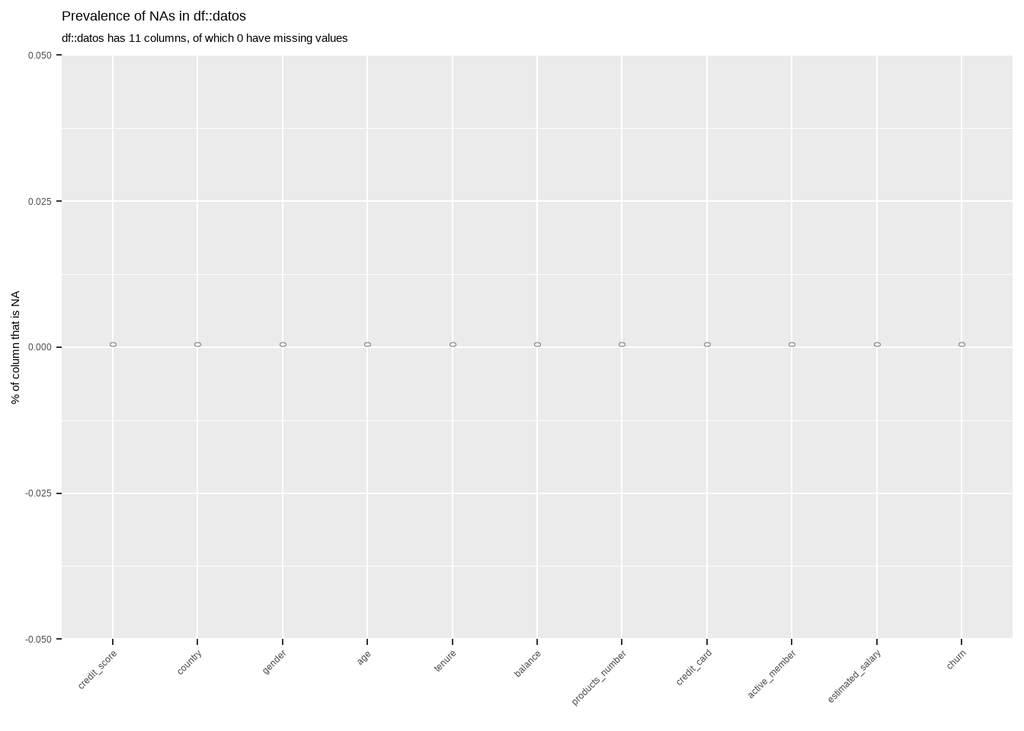

```r
show_plot(inspect_na(datos))
```

## 4. ANÁLISIS DE VARIABLES NUMÉRICAS Y DISCRETAS:

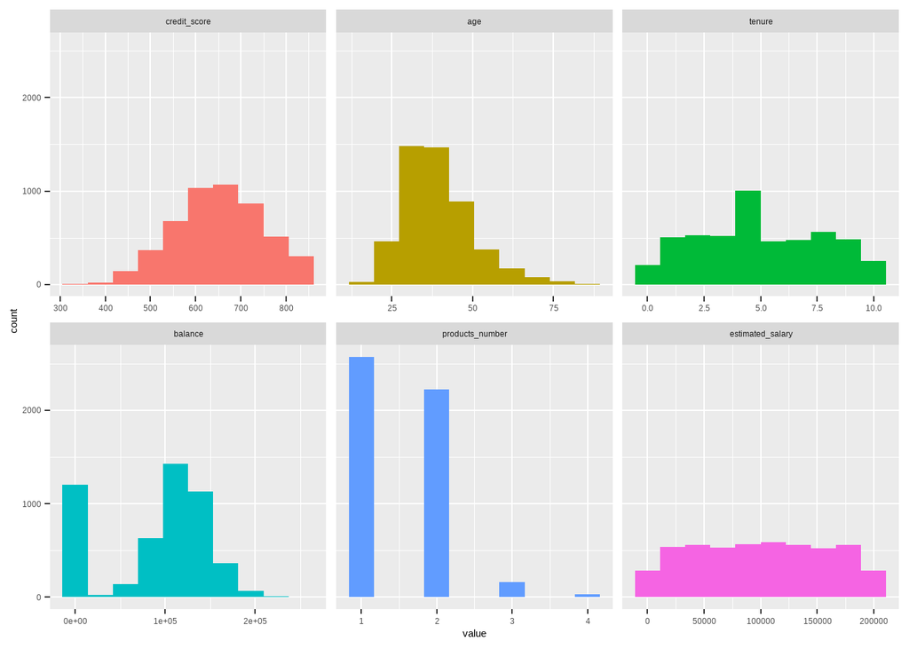

```r
# Graficamos las distribuciones de las variables numéricas

plot_num(datos)
```

- Vemos que la variable AGE(edad) tiene un poquito de cola hacia los clientes con más edad.
- Observamos la columna de CEROS de la variable BALANCE como comentamos anteriormente.
- Tambien comprobamos que la mayoría de clientes tienen 1 ó 2 productos contratados solamente con el banco.
- Es importante ver la relación entre los niveles de nuestra variable objetivo y nuestras variables explicativas, ya que podemos deducir información muy importante. Para ello, en el caso de las variables explicativas númericas, los gráficos boxplot son muy útiles e intuitivos: cuanto menos se solapen las cajas y más alejadas estén las medianas para una variable independiente, podemos establecer la hipótesis de que la misma, tendrá más influencia en la evolución de la variable dependiente.

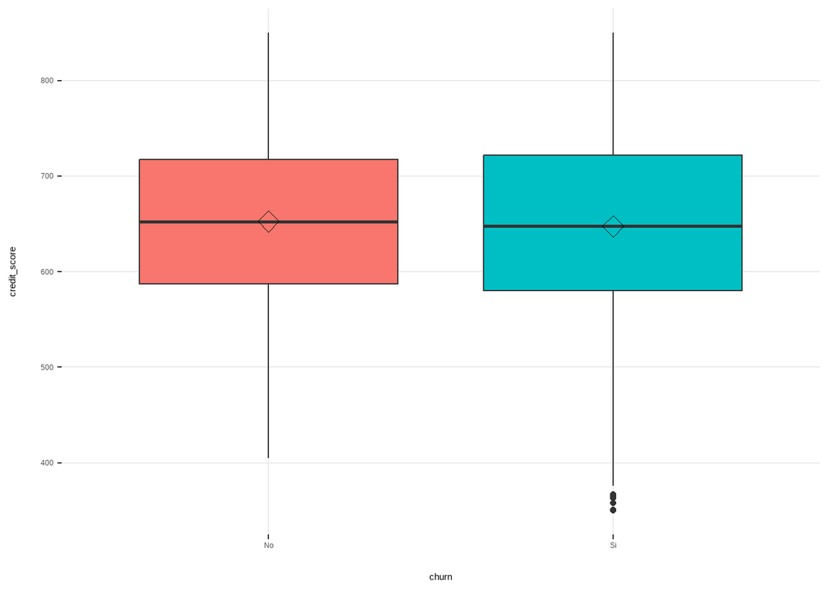

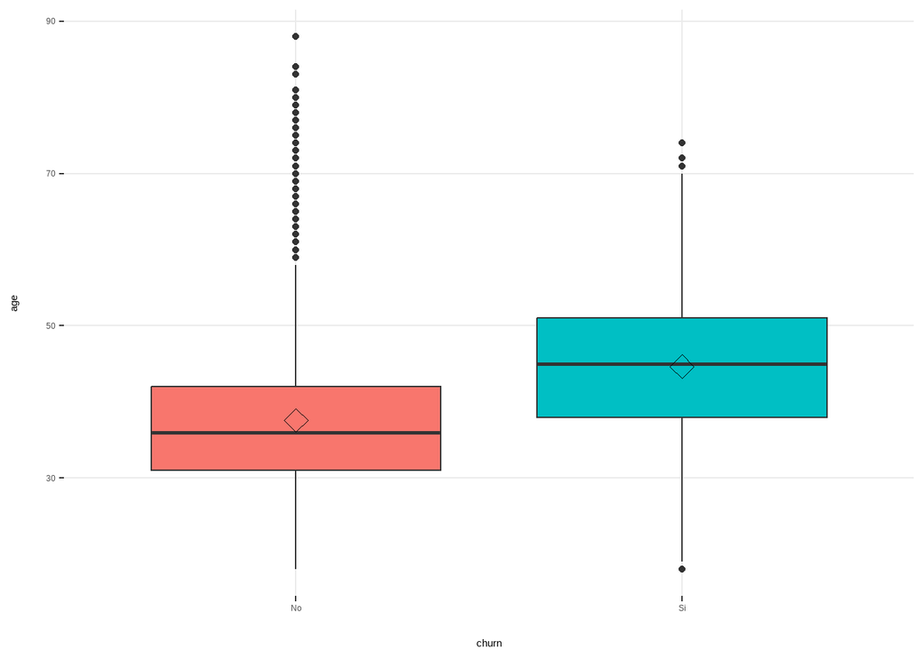

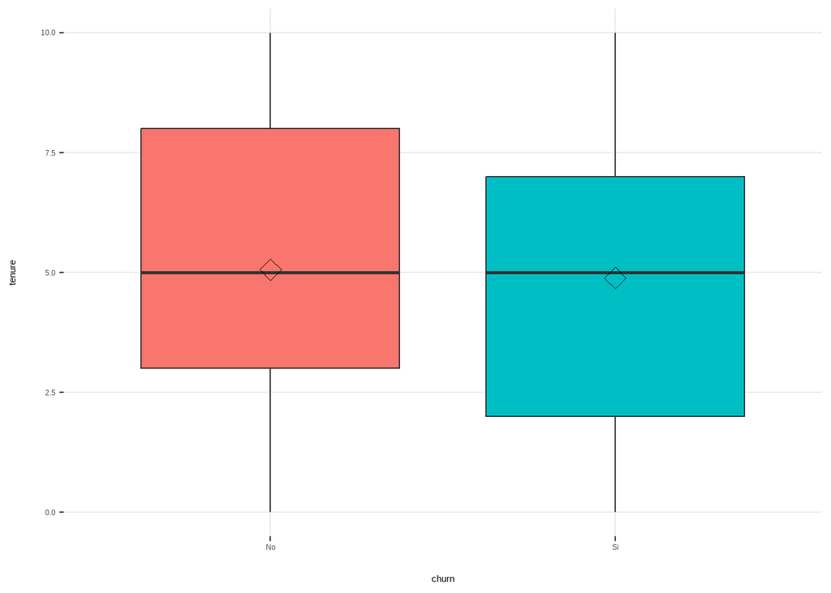

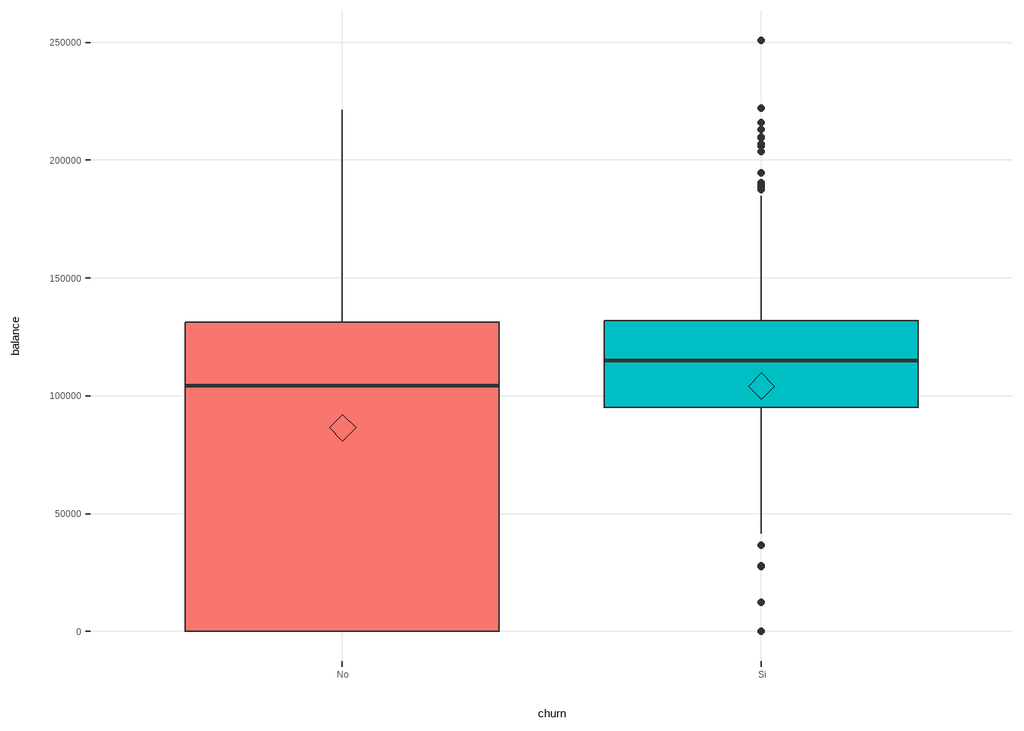

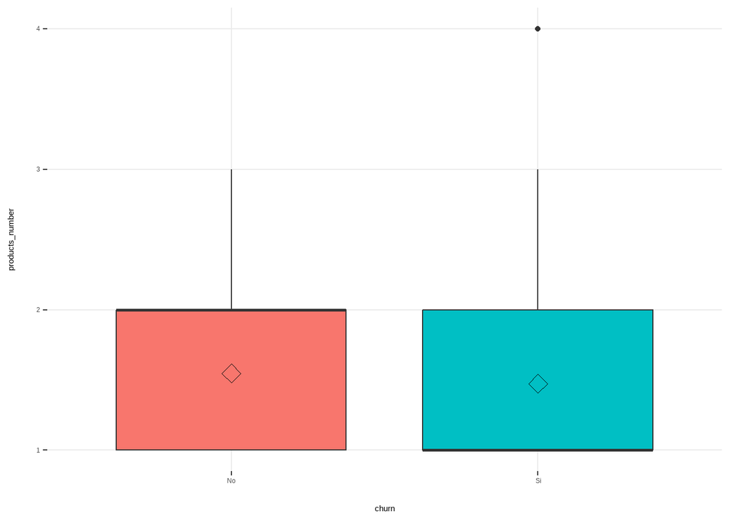

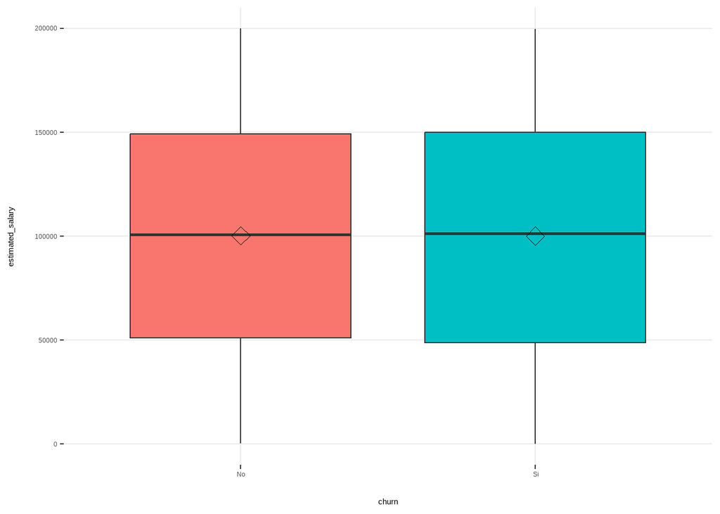

```r
# variables numéricas en función de la variable categórica que queremos estudiar:
plotar(data = datos, target = "churn", plot_type = "boxplot")
```

A simple vista, parece que las variables más significativas o que más discriminan la variable clase, son: la EDAD, el BALANCE (saldo en cuenta), y el número de productos contratados (PRODUCTS_NUMBER). Como corroboramos a continuación con las gráficas de densidad.

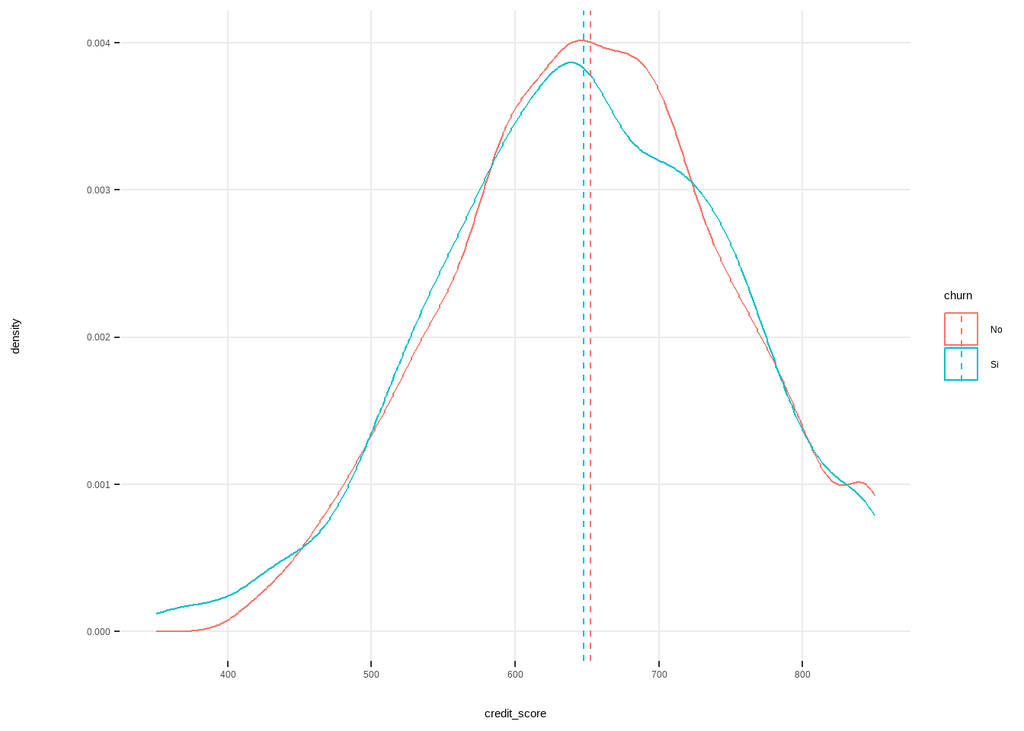

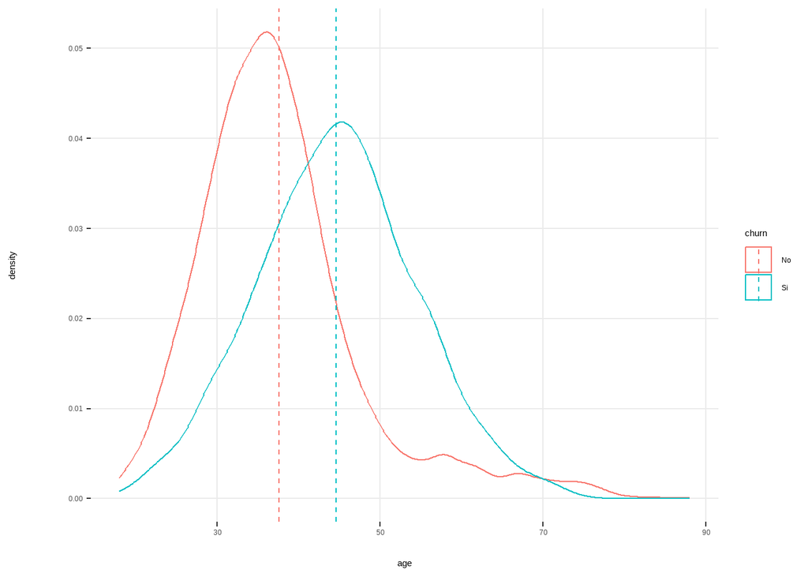

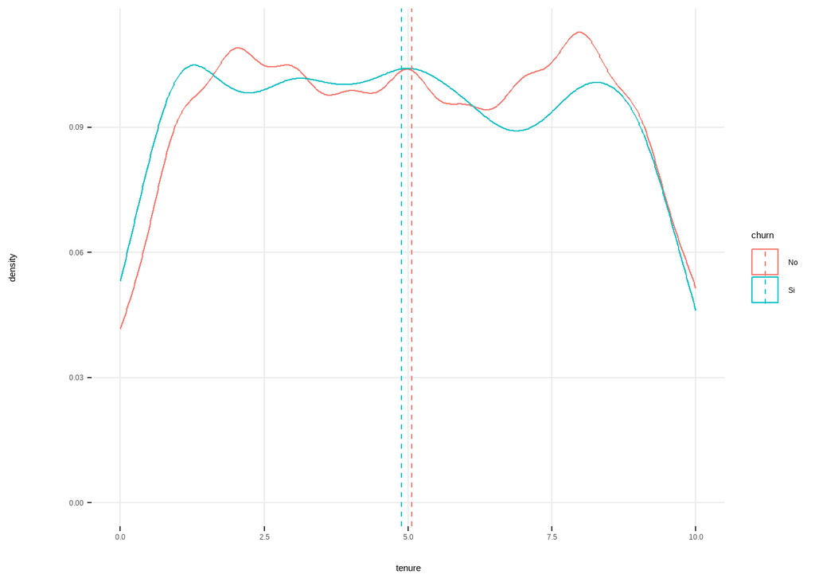

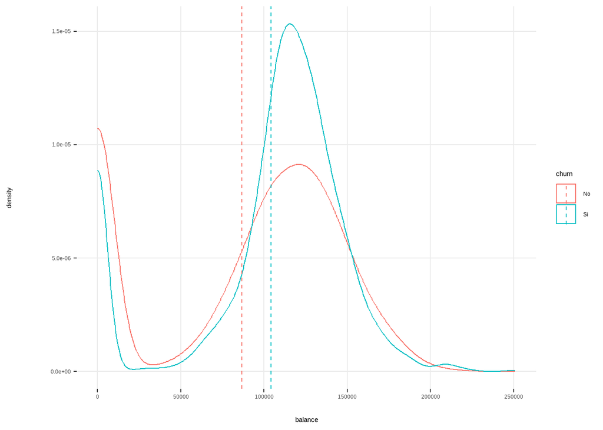

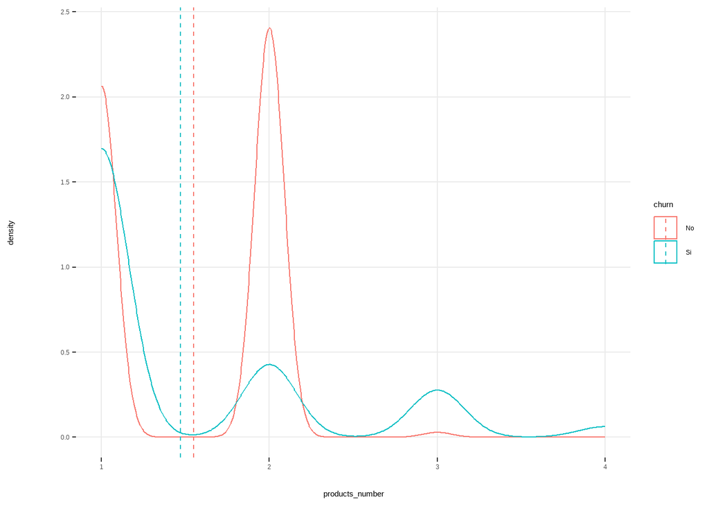

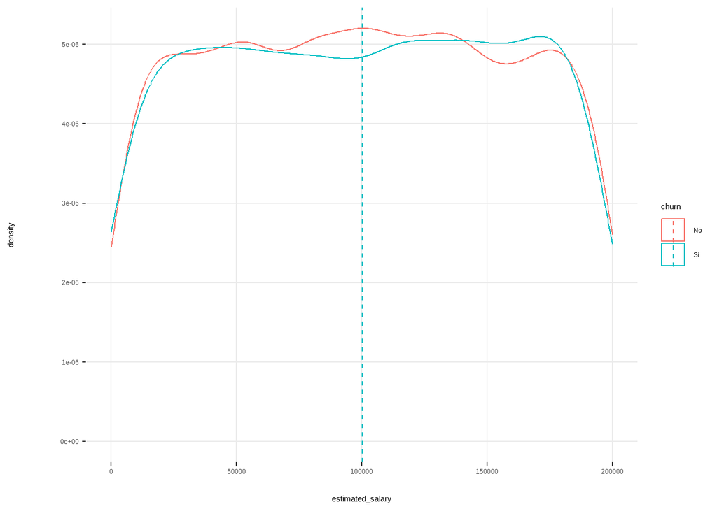

```r
plotar(datos, target= "churn", plot_type="histdens")
```

## 5. ESTUDIO DE VALORES ANÓMALOS (OUTLIERS):

Los comandos diagnose_outlier y plot_outlier de la librería dlook nos proporciona un excelente diagnóstico gráfico con y sin outliers que nos puede facilitar tomar decisiones correctas sobre los valores anómalos y qué variables podrían interesarnos o no imputar.

```r
datos %>%
    diagnose_outlier(credit_score,age,tenure,balance, products_number,estimated_salary)%>%
  kable() %>%
  kable_styling(bootstrap_options = 'striped', font_size = 12, full_width = F) %>%
  scroll_box(width = "100%")
```

| variables | outliers_cnt | outliers_ratio | outliers_mean | with_mean | without_mean |
| --- | --- | --- | --- | --- | --- |
| credit_score | 11 | 0.2206177 | 366.45455 | 6.513941e+02 | 6.520241e+02 |
| age | 141 | 2.8279182 | 70.58865 | 3.933414e+01 | 3.842456e+01 |
| tenure | 0 | 0.0000000 | NaN | 5.021059e+00 | 5.021059e+00 |
| balance | 1 | 0.0200562 | 250898.09000 | 9.095997e+04 | 9.092789e+04 |
| products_number | 31 | 0.6217409 | 4.00000 | 1.529483e+00 | 1.514026e+00 |
| estimated_salary | 0 | 0.0000000 | NaN | 1.002824e+05 | 1.002824e+05 |

Las variables TENURE(años como clientes) y ESTIMATED_SALARY(sueldo estimado) no tienen outliers. La variable BALANCE(saldo en cuenta) tiene un solo outlier, que debe ser el saldo de la cuenta de un cliente que destaca bastante de los demás. En realidad, no cambia mucho el estudio si lo cambiamos por el valor superior del umbral.

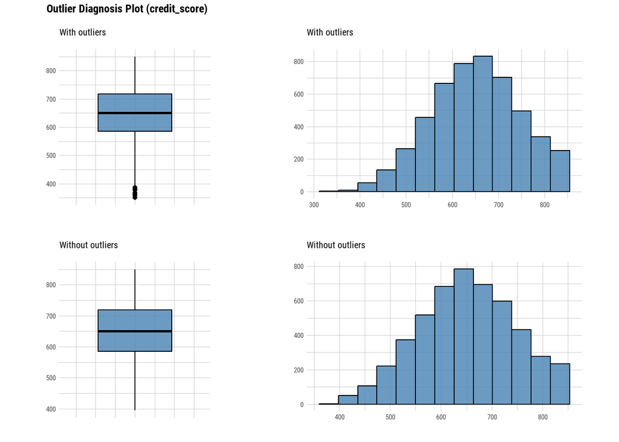

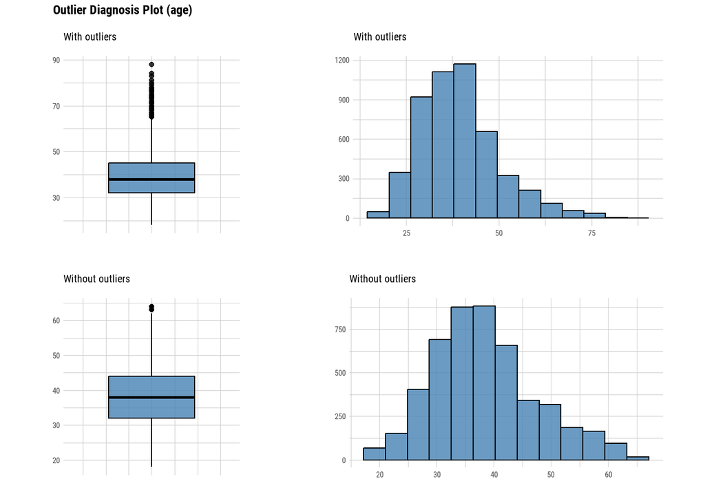

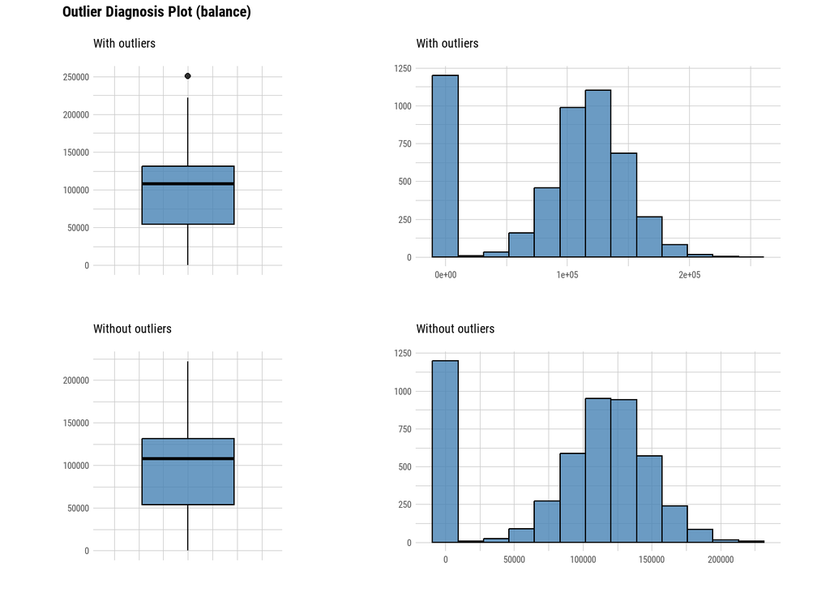

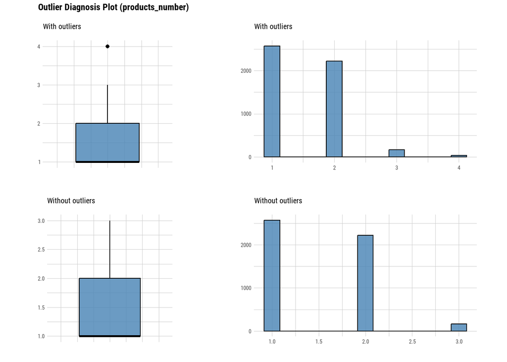

```r
datos %>%
    plot_outlier(credit_score,age,balance, products_number)
```

Prácticamente no varían las distribuciones de las variables si eliminamos los outliers.

Así que, vamos a tratarlos a continuación: Con la función prep_outliers vamos a preparar un fichero realizando alguna acción sobre los valores outliers. Si especificamos el valor de type = stop todos los valores que estén más allá del umbral se convertirán al umbral.

```r
variables = c("credit_score","balance", "products_number","age")
var_stop_bottom_top <- prep_outliers(data=datos,
                                       input=variables,
                                       type='stop', top_percent  = 0.01,method = "bottom_top")

# Comprobamos ahora que no se han asignado valores missing

sapply(var_stop_bottom_top, function(x) sum(is.na(x)))
```

```
##     credit_score          country           gender              age
##                0                0                0                0
##           tenure          balance  products_number      credit_card
##                0                0                0                0
##    active_member estimated_salary            churn
##                0                0                0
```

```r
datos_limpios<-var_stop_bottom_top
str(datos_limpios)
```

```
## 'data.frame':    4986 obs. of  11 variables:
##  $ credit_score    : num  608 850 645 376 497 635 616 653 549 587 ...
##  $ country         : Factor w/ 2 levels "Germany","Spain": 2 2 2 1 2 2 1 1 2 2 ...
##  $ gender          : Factor w/ 2 levels "Female","Male": 1 1 2 1 2 1 2 2 1 2 ...
##  $ age             : num  41 43 44 29 24 35 45 58 24 45 ...
##  $ tenure          : int  1 2 8 4 3 7 3 1 9 6 ...
##  $ balance         : num  83808 125511 113756 115047 0 ...
##  $ products_number : num  1 1 2 3 2 2 2 1 2 1 ...
##  $ credit_card     : Factor w/ 2 levels "No","Si": 1 2 2 2 2 2 1 2 2 1 ...
##  $ active_member   : Factor w/ 2 levels "No","Si": 2 2 1 1 1 2 2 1 2 1 ...
##  $ estimated_salary: num  112543 79084 149757 119347 76390 ...
##  $ churn           : Factor w/ 2 levels "No","Si": 1 1 2 2 1 1 1 2 1 1 ...
```

A partir de ahora trabajaremos con la base de datos: “datos_limpios”.

## 6. ANÁLISIS DE LAS VARIABLES CATEGÓRICAS:

Utilizamos el comando freq de la librería funModeling para sacar los porcentajes de cada categoría de las variables, después aplicamos el comando crossplot para ampliar la visualización gráfica obteniendo la representación de las variables categóricas en relación con la variable objetivo.

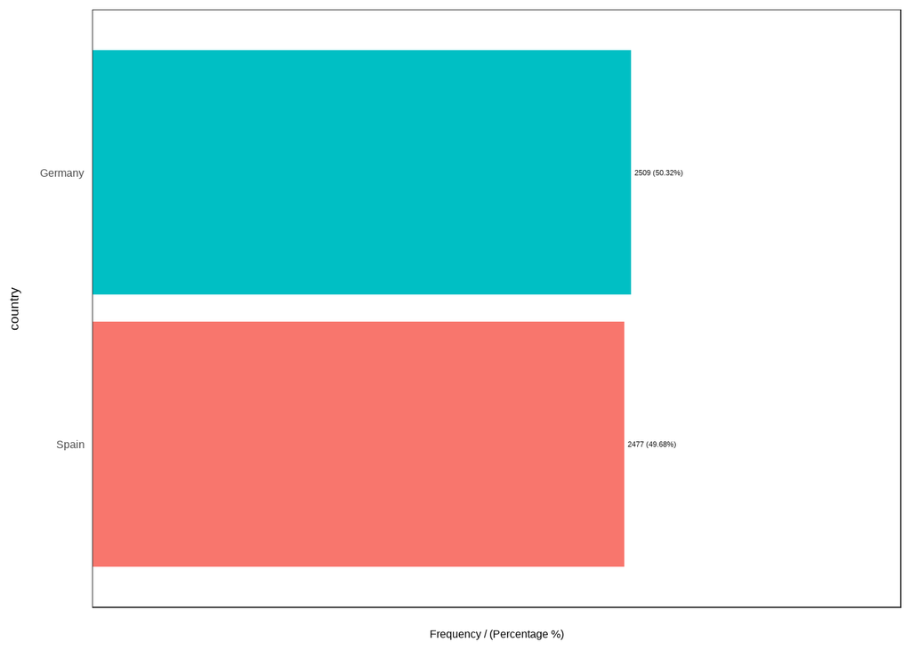

```
##   country frequency percentage cumulative_perc
## 1 Germany      2509      50.32           50.32
## 2   Spain      2477      49.68          100.00
```

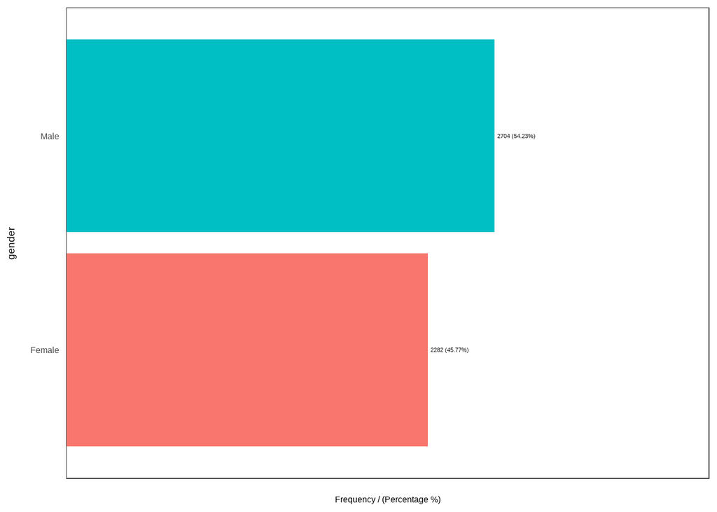

```
##   gender frequency percentage cumulative_perc
## 1   Male      2704      54.23           54.23
## 2 Female      2282      45.77          100.00
```

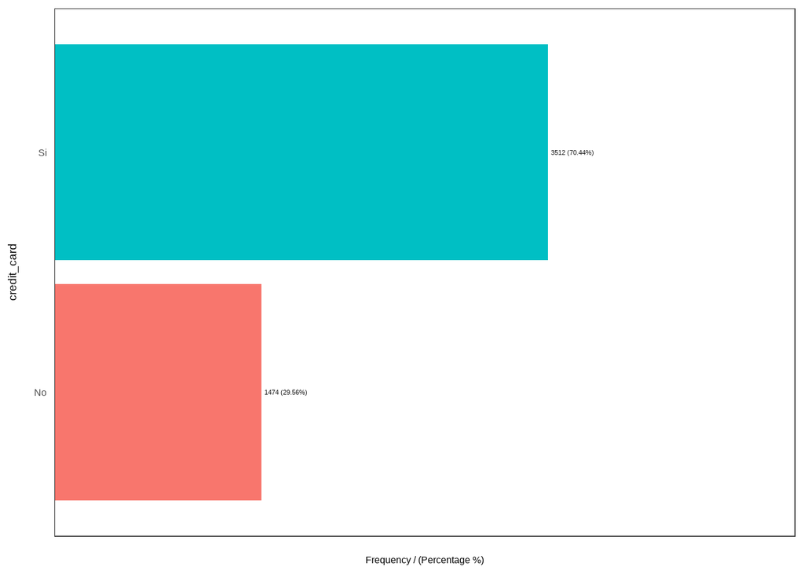

```
##   credit_card frequency percentage cumulative_perc
## 1          Si      3512      70.44           70.44
## 2          No      1474      29.56          100.00
```

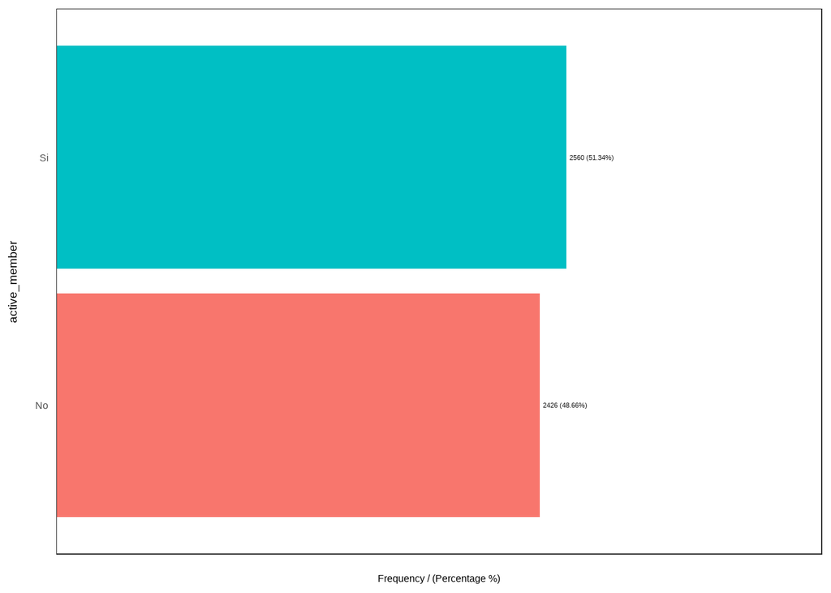

```
##   active_member frequency percentage cumulative_perc
## 1            Si      2560      51.34           51.34
## 2            No      2426      48.66          100.00
```

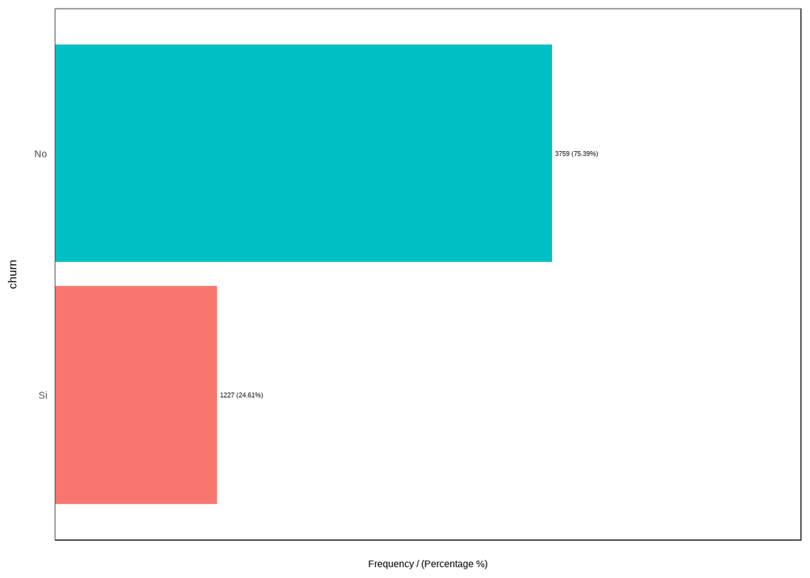

```
##   churn frequency percentage cumulative_perc
## 1    No      3759      75.39           75.39
## 2    Si      1227      24.61          100.00
```

```
## [1] "Variables processed: country, gender, credit_card, active_member, churn"
```

```r
freq(datos_limpios)
```

```r
categoricas <- datos_limpios %>% select (country, gender, credit_card, active_member, churn)

categ_analysis(categoricas, target = "churn")
```

```
##   country mean_target sum_target perc_target q_rows perc_rows
## 1 Germany       0.324        814       0.663   2509     0.503
## 2   Spain       0.167        413       0.337   2477     0.497
##
##   gender mean_target sum_target perc_target q_rows perc_rows
## 1 Female       0.298        679       0.553   2282     0.458
## 2   Male       0.203        548       0.447   2704     0.542
##
##   credit_card mean_target sum_target perc_target q_rows perc_rows
## 1          No       0.252        372       0.303   1474     0.296
## 2          Si       0.243        855       0.697   3512     0.704
##
##   active_member mean_target sum_target perc_target q_rows perc_rows
## 1            No       0.326        790       0.644   2426     0.487
## 2            Si       0.171        437       0.356   2560     0.513
```

```
## [1] "Variables processed: country, gender, credit_card, active_member"
```

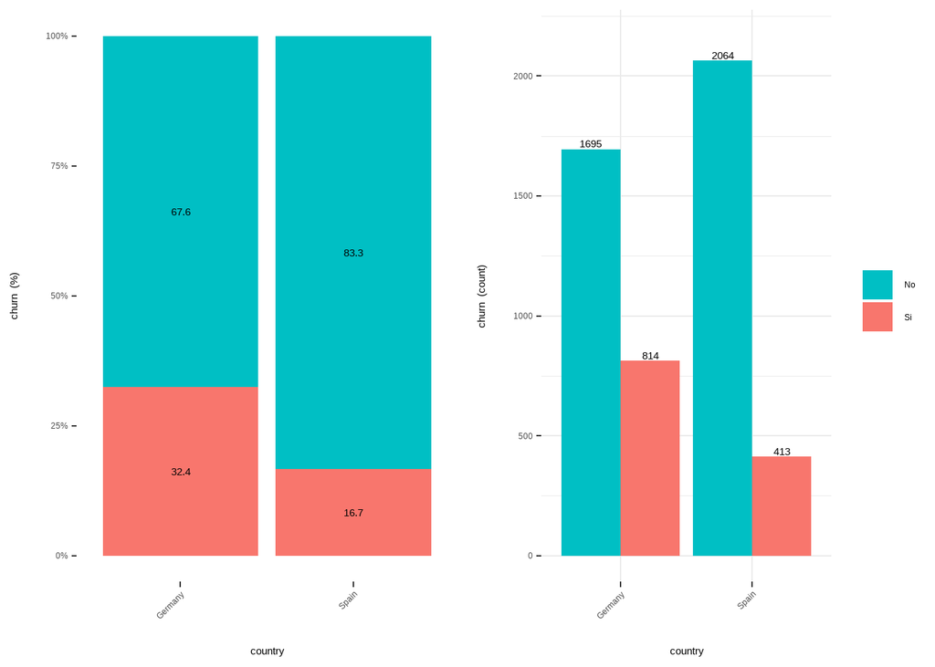

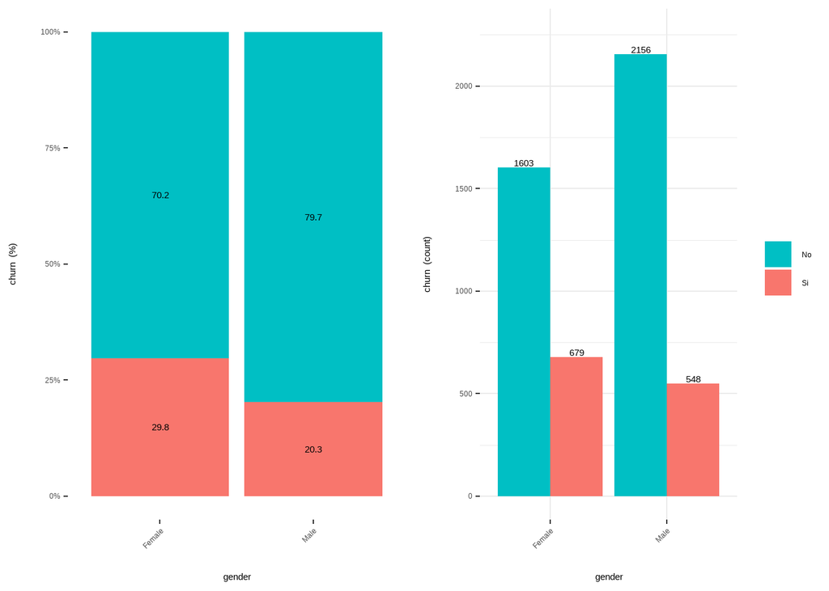

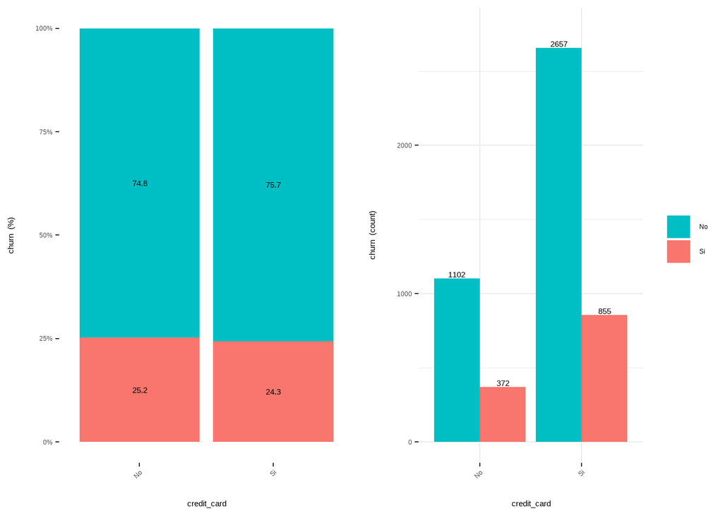

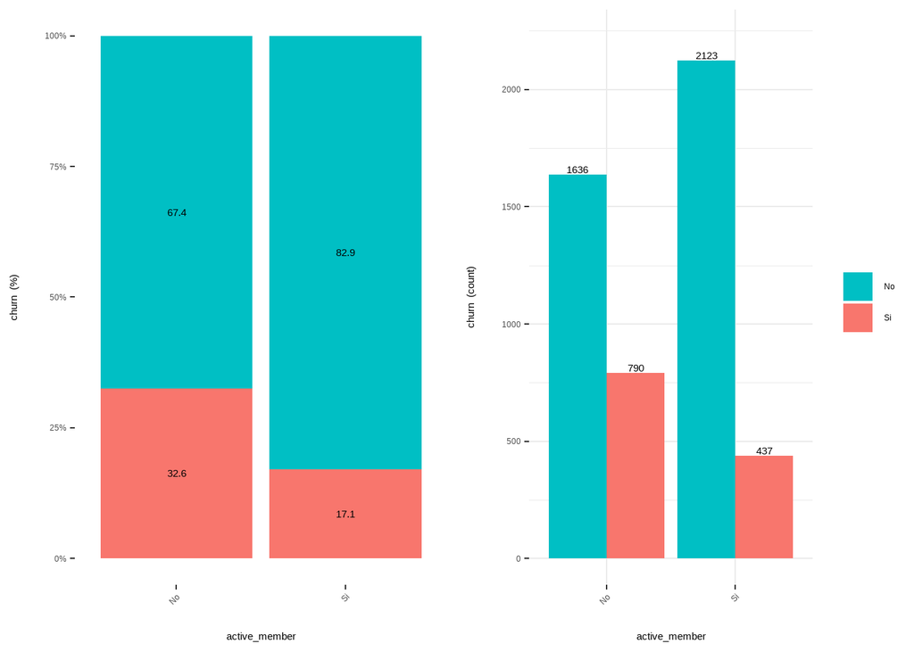

```r
cross_plot(categoricas, target = "churn", auto_binning = TRUE )
```

### Contraste de tablas de contingencia estadísticas:

- Vemos las relaciones entre el país(COUNTRY) desde donde se opera y el abandono del banco(CHURN) y de sus servicios:

```r
t1 <- table(datos_limpios$country,datos_limpios$churn)
      addmargins(t1)
```

```
##
##             No   Si  Sum
##   Germany 1695  814 2509
##   Spain   2064  413 2477
##   Sum     3759 1227 4986
```

```r
# Contraste tabla de contingencia.

a = chisq.test(datos_limpios$country,datos_limpios$churn)

print(a)
```

```
##
##  Pearson's Chi-squared test with Yates' continuity correction
##
## data:  datos_limpios$country and datos_limpios$churn
## X-squared = 166.23, df = 1, p-value < 2.2e-16
```

La conclusión que se extrae es que no son independientes, es decir, que existe cierto grado de asociación entre el PAIS del cliente y el ABANDONO del banco.

- Vemos las relaciones entre ACTIVE_MEMBER(si es un cliente activo o no) y el abandono del banco(CHURN) y de sus servicios:

```r
t2 <- table(datos_limpios$active_member,datos_limpios$churn)
      addmargins(t2)
```

```
##
##         No   Si  Sum
##   No  1636  790 2426
##   Si  2123  437 2560
##   Sum 3759 1227 4986
```

```r
# Contraste tabla de contingencia.

b = chisq.test(datos_limpios$active_member,datos_limpios$churn)

print(b)
```

```
##
##  Pearson's Chi-squared test with Yates' continuity correction
##
## data:  datos_limpios$active_member and datos_limpios$churn
## X-squared = 160.33, df = 1, p-value < 2.2e-16
```

La conclusión que se extrae es que no son independientes, es decir, que existe cierto grado de asociación entre si es un cliente activo o no y el ABANDONO del banco.

## 7. ANÁLISIS DE LAS CORRELACIONES:

Vamos a proceder al estudio de la correlación de las variables numéricas. Esperando encontrar algún indicador alto de correlación o alguna combinación lineal entre ellas que pueda realizar PCA.

```r
var_num<-select(datos_limpios,c(credit_score,age,tenure,balance, products_number,estimated_salary))
cor(var_num)%>%
  kable() %>%
  kable_styling(bootstrap_options = 'striped', font_size = 12, full_width = F) %>%
  scroll_box(width = "100%")
```

|  | credit_score | age | tenure | balance | products_number | estimated_salary |
| --- | --- | --- | --- | --- | --- | --- |
| credit_score | 1.0000000 | -0.0066268 | -0.0019742 | -0.0133506 | 0.0096292 | -0.0130456 |
| age | -0.0066268 | 1.0000000 | -0.0234470 | 0.0452532 | -0.0481821 | 0.0035162 |
| tenure | -0.0019742 | -0.0234470 | 1.0000000 | -0.0077078 | 0.0076386 | 0.0245735 |
| balance | -0.0133506 | 0.0452532 | -0.0077078 | 1.0000000 | -0.2330035 | 0.0118222 |
| products_number | 0.0096292 | -0.0481821 | 0.0076386 | -0.2330035 | 1.0000000 | 0.0045959 |
| estimated_salary | -0.0130456 | 0.0035162 | 0.0245735 | 0.0118222 | 0.0045959 | 1.0000000 |

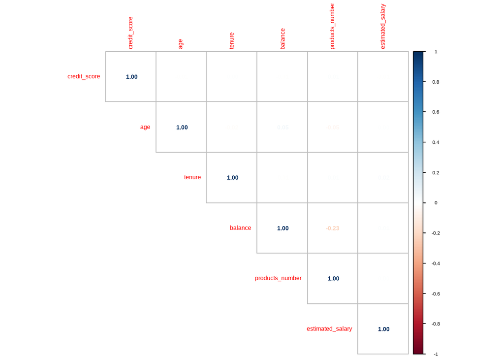

```r
correlacion<- round(cor(var_num, use='complete.obs'), 2)
corrplot(correlacion, type='upper', method = 'number')
```

Podemos ver en la gráfica que no hay ningún tipo de correlación entre las variables numéricas. Así que no podemos realizar un PCA para la selección de las variables más relevantes.

## 8. SELECCIÓN DE VARIABLES:

En principio las variables más representativas y significativas para el estudio, después del estudio analítico, parecen ser:

CUANTITATIVAS age, balance y products_number.

CUALITATIVAS country y active_member

No obstante, a través de la regresión logística y del método de selección de variables por pasos con el criterio de Información de Akaike obtendremos el conjunto de variables para construir el método del cubo. Y lo compararemos con nuestras conclusiones de los resultados analíticos.

```r
library(MASS)
modelo.glm <- glm(churn ~ credit_score+ age+ balance+tenure+ products_number+ estimated_salary+ country+ gender+ credit_card+active_member, data = datos_limpios, family=binomial)

modelo.stp <- stepAIC(modelo.glm, scope = list(upper = modelo.glm$formula, lower = ~1), direction = "both")
```

```
## Start:  AIC=4709.65
## churn ~ credit_score + age + balance + tenure + products_number +
##     estimated_salary + country + gender + credit_card + active_member
##
##                    Df Deviance    AIC
## - estimated_salary  1   4688.0 4708.0
## - credit_card       1   4688.6 4708.6
## - credit_score      1   4688.9 4708.9
## <none>                  4687.6 4709.6
## - tenure            1   4692.1 4712.1
## - balance           1   4695.5 4715.5
## - products_number   1   4699.3 4719.3
## - gender            1   4731.6 4751.6
## - country           1   4770.0 4790.0
## - active_member     1   4904.9 4924.9
## - age               1   5145.0 5165.0
##
## Step:  AIC=4708.04
## churn ~ credit_score + age + balance + tenure + products_number +
##     country + gender + credit_card + active_member
##
##                    Df Deviance    AIC
## - credit_card       1   4689.0 4707.0
## - credit_score      1   4689.3 4707.3
## <none>                  4688.0 4708.0
## + estimated_salary  1   4687.6 4709.6
## - tenure            1   4692.6 4710.6
## - balance           1   4695.9 4713.9
## - products_number   1   4699.8 4717.8
## - gender            1   4731.8 4749.8
## - country           1   4770.3 4788.3
## - active_member     1   4905.1 4923.1
## - age               1   5145.2 5163.2
##
## Step:  AIC=4707.02
## churn ~ credit_score + age + balance + tenure + products_number +
##     country + gender + active_member
##
##                    Df Deviance    AIC
## - credit_score      1   4690.2 4706.2
```

[output cut: 12 more lines]

```
## churn ~ age + balance + tenure + products_number + country +
##     gender + active_member
##
##                    Df Deviance    AIC
## <none>                  4690.2 4706.2
## + credit_score      1   4689.0 4707.0
## + credit_card       1   4689.3 4707.3
## + estimated_salary  1   4689.8 4707.8
## - tenure            1   4694.9 4708.9
## - balance           1   4698.2 4712.2
## - products_number   1   4702.0 4716.0
## - gender            1   4733.6 4747.6
## - country           1   4771.9 4785.9
## - active_member     1   4907.6 4921.6
## - age               1   5148.4 5162.4
```

```r
modelo.stp$formula
```

```
## churn ~ age + balance + tenure + products_number + country +
##     gender + active_member
```

Vemos que en el modelo de selección de variables a través de la regresión logística, nos quedamos con 7 variables:

AGE, BALANCE, TENURE, PRODUCTS_NUMBER, COUNTRY, GENDER Y ACTIVE_MEMBER. Dos variables más que las que habíamos estimado.

## 9. BALANCEO DE LA MUESTRA:

Una vez realizado el análisis estadístico y el preprocesado de la información de la muestra vamos a proceder a balancear la base de datos con las variables obtenidas en el apartado anterior. Vamos a tomar una muestra de 1227 clientes, para no tener que hacer sobremuestreo que falsea la realidad.

```r
library(sampling)
# Datos donde efectuamos seleccion (no abandonan)

datos_limpios.no <- datos_limpios[ datos_limpios$churn == 'No', ]

# Numero de casos no abandonan
n.datos.no <- nrow( datos_limpios.no )

# Creamos las variables indicadores para cada una de las variables de equilibrio.

# Variable que vale 1 en todas las partes (para comprobar la estimación del Tamaño poblacional)
UNO = rep( 1, dim( datos_limpios.no )[ 1 ] )

# Variables cuantitativas
X1 <- datos_limpios.no[ , c( "age", "balance", "tenure", "products_number" ) ]

# COUNTRY
disjunctive(datos_limpios.no$country) -> X2
colnames(X2) <- levels(datos_limpios.no$country)

# GENDER
disjunctive(datos_limpios.no$gender) -> X3
colnames(X3) <- levels(datos_limpios.no$gender)

# ACTIVE_MEMBER
disjunctive(datos_limpios.no$active_member) -> X4
colnames(X4) <- levels(datos_limpios.no$active_member)

# Matriz de diseño
X <- as.matrix( cbind( UNO, X1, X2, X3, X4 ) )

# Tamaño de la muestra
s.datos.no <- 1227

# Probabilidades de inclusión
pik = rep( s.datos.no / n.datos.no, n.datos.no )

# extracci?n de la muestra
set.seed( 123456 )
s = samplecube( X, pik, method = 2, order = 1, comment = FALSE ) # Para que no nos saque los resultados

##Calidad de la muestra
Totales <- apply(X, 2, sum)
Horvitz.Thompson <- apply(X * s / pik, 2, sum)
calidad <- cbind.data.frame(Totales, Horvitz.Thompson)
calidad$Desv.Abs. <- round(calidad$Totales - calidad$Horvitz.Thompson, 2)
calidad$Desv.Rel. <- round((calidad$Totales / calidad$Horvitz.Thompson - 1) *100, 2)
print(as.matrix.data.frame(calidad))
```

```
##                   Totales Horvitz.Thompson  Desv.Abs. Desv.Rel.
## UNO                  3759     3.759000e+03       0.00      0.00
## age                141170     1.411632e+05       6.84      0.00
## balance         325268827     3.254057e+08 -136862.14     -0.04
## tenure              19037     1.902783e+04       9.17      0.05
## products_number      5817     5.817719e+03      -0.72     -0.01
## Germany              1695     1.694154e+03       0.85      0.05
## Spain                2064     2.064846e+03      -0.85     -0.04
## Female               1603     1.602247e+03       0.75      0.05
## Male                 2156     2.156753e+03      -0.75     -0.03
## No                   1636     1.635946e+03       0.05      0.00
## Si                   2123     2.123054e+03      -0.05      0.00
```

```r
##Generación del fichero resultante

muestra.no = cbind( datos_limpios.no, s )
muestra.no <- muestra.no[muestra.no$s == 1,]
muestra.no$s  <- NULL
```

```r
str(muestra.no)
```

```
## 'data.frame':    1227 obs. of  11 variables:
##  $ credit_score    : num  660 550 776 698 725 555 661 757 773 528 ...
##  $ country         : Factor w/ 2 levels "Germany","Spain": 2 1 1 1 1 2 1 2 2 2 ...
##  $ gender          : Factor w/ 2 levels "Female","Male": 1 2 1 2 2 2 1 2 2 2 ...
##  $ age             : num  61 38 37 44 19 33 35 33 41 36 ...
##  $ tenure          : int  5 2 2 10 0 1 5 5 9 7 ...
##  $ balance         : num  155931 103391 103769 116363 75888 ...
##  $ products_number : num  1 1 2 2 1 2 2 1 1 2 ...
##  $ credit_card     : Factor w/ 2 levels "No","Si": 2 1 2 2 1 1 1 1 1 2 ...
##  $ active_member   : Factor w/ 2 levels "No","Si": 2 2 1 1 1 1 2 2 2 1 ...
##  $ estimated_salary: num  158338 90878 194099 198059 45614 ...
##  $ churn           : Factor w/ 2 levels "No","Si": 1 1 1 1 1 1 1 1 1 1 ...
```

- Ahora la parte de la muestra cuya salida es “sí” la obtenemos:

```r
datos_limpios.si <- datos_limpios[ datos_limpios$churn == 'Si',]
str(datos_limpios.si)
```

```
## 'data.frame':    1227 obs. of  11 variables:
##  $ credit_score    : num  645 376 653 510 591 829 637 655 601 511 ...
##  $ country         : Factor w/ 2 levels "Germany","Spain": 2 1 1 2 2 1 1 1 1 2 ...
##  $ gender          : Factor w/ 2 levels "Female","Male": 2 1 2 1 1 1 1 2 2 1 ...
##  $ age             : num  44 29 58 38 39 27 39 41 42 66 ...
##  $ tenure          : int  8 4 1 4 3 9 9 8 1 4 ...
##  $ balance         : num  113756 115047 132603 0 0 ...
##  $ products_number : num  2 3 1 1 3 1 1 1 1 1 ...
##  $ credit_card     : Factor w/ 2 levels "No","Si": 2 2 2 2 2 2 2 1 2 2 ...
##  $ active_member   : Factor w/ 2 levels "No","Si": 1 1 1 1 1 2 2 1 1 1 ...
##  $ estimated_salary: num  149757 119347 5098 118914 140469 ...
##  $ churn           : Factor w/ 2 levels "No","Si": 2 2 2 2 2 2 2 2 2 2 ...
```

- La muestra final equilibrada será la unión de las dos muestras anteriores:

```r
# Data frame resultante
muestra <- rbind( muestra.no, datos_limpios.si )

str(muestra)
```

```
## 'data.frame':    2454 obs. of  11 variables:
##  $ credit_score    : num  660 550 776 698 725 555 661 757 773 528 ...
##  $ country         : Factor w/ 2 levels "Germany","Spain": 2 1 1 1 1 2 1 2 2 2 ...
##  $ gender          : Factor w/ 2 levels "Female","Male": 1 2 1 2 2 2 1 2 2 2 ...
##  $ age             : num  61 38 37 44 19 33 35 33 41 36 ...
##  $ tenure          : int  5 2 2 10 0 1 5 5 9 7 ...
##  $ balance         : num  155931 103391 103769 116363 75888 ...
##  $ products_number : num  1 1 2 2 1 2 2 1 1 2 ...
##  $ credit_card     : Factor w/ 2 levels "No","Si": 2 1 2 2 1 1 1 1 1 2 ...
##  $ active_member   : Factor w/ 2 levels "No","Si": 2 2 1 1 1 1 2 2 2 1 ...
##  $ estimated_salary: num  158338 90878 194099 198059 45614 ...
##  $ churn           : Factor w/ 2 levels "No","Si": 1 1 1 1 1 1 1 1 1 1 ...
```

```r
table(muestra$churn)
```

```
##
##   No   Si
## 1227 1227
```

**El dataset con el que trabajaremos será: “muestra”, donde ya tenemos los datos limpios y balanceados.**

## 10. ESCALADO Y CENTRADO DE LAS VARIABLES:

Dado que las variables numéricas presentan rangos de valores muy diferentes procedemos a centrarlas y escalarlas.

```r
datos_escalados <- scale(muestra[,c(1,4,5,6,7,10)], center = T, scale = T)

muestra <- cbind(datos_escalados, muestra[,c(2,3,8,9,11)])

head(muestra, 10) %>%
  kable() %>%
  kable_styling(bootstrap_options = 'striped', font_size = 12, full_width = F) %>%
  scroll_box(width = "100%")
```

|  | credit_score | age | tenure | balance | products_number | estimated_salary | country | gender | credit_card | active_member | churn |
| --- | --- | --- | --- | --- | --- | --- | --- | --- | --- | --- | --- |
| 23 | 0.1062949 | 1.8911403 | 0.0085336 | 1.1277494 | -0.7935543 | 1.0035115 | Spain | Female | Si | Si | No |
| 27 | -1.0268404 | -0.2943133 | -1.0213725 | 0.1506445 | -0.7935543 | -0.1602723 | Germany | Male | No | Si | No |
| 28 | 1.3012376 | -0.3893331 | -1.0213725 | 0.1576714 | 0.7987452 | 1.6204340 | Germany | Female | Si | No | No |
| 29 | 0.4977417 | 0.2758050 | 1.7250438 | 0.3918904 | 0.7987452 | 1.6887503 | Germany | Male | Si | No | No |
| 33 | 0.7758749 | -2.0996881 | -1.7079766 | -0.3608445 | -0.7935543 | -0.9411462 | Germany | Male | No | No | No |
| 37 | -0.9753342 | -0.7694120 | -1.3646746 | -0.7291392 | 0.7987452 | 1.3564706 | Spain | Male | No | No | No |
| 43 | 0.1165962 | -0.5793725 | 0.0085336 | 1.0309389 | 0.7987452 | 0.2326924 | Germany | Female | No | Si | No |
| 47 | 1.1055142 | -0.7694120 | 0.0085336 | -0.3354586 | -0.7935543 | 1.6228580 | Spain | Male | No | Si | No |
| 55 | 1.2703339 | -0.0092542 | 1.3817418 | 0.1401566 | -0.7935543 | -0.6136888 | Spain | Male | No | Si | No |
| 58 | -1.2534674 | -0.4843528 | 0.6951377 | -1.7721713 | 0.7987452 | -0.6837068 | Spain | Male | Si | No | No |

```r
rm(datos_escalados)
```

## 11. CREACIÓN DE LOS DATASETS PARA LOS MODELOS:

```r
# Este fichero data_1 contiene todas las variables. Cambiamos el nombre de la variable "respuesta" por "y"


colnames(muestra)[11]<-"y"
```

Tenemos un conjunto de datos mixto: con variables numéricas y categóricas. La mayoría de los modelos trabajan solo con variables numéricas internamente, pero algunos bayesianos necesitan que todas sean categóricas. Vamos a crear un conjunto de datos para cada caso.

Guardamos los diferentes ficheros:

- Conjuntos de datos numéricos y categóricos:

data_1.csv : el dataset de la muestra final con los datos limpios, balanceados y escalados.

```r
write.csv(muestra, file = 'data_1.csv',row.names = FALSE)
```

- Factorización con MDLP:

datos_bayes.csv : dataset factorizado para utilizarlo en Redes Bayesianas.

```r
muestra1.disc <- discretizeDF.supervised(y ~ ., muestra)

write.csv(muestra1.disc, file = 'datos_bayes.csv',row.names = FALSE)

str(muestra1.disc)
```

```
## 'data.frame':    2454 obs. of  11 variables:
##  $ credit_score    : Factor w/ 2 levels "[-Inf,-2.53)",..: 2 2 2 2 2 2 2 2 2 2 ...
##   ..- attr(*, "discretized:breaks")= num [1:3] -Inf -2.53 Inf
##   ..- attr(*, "discretized:method")= chr "mdlp"
##  $ age             : Factor w/ 5 levels "[-Inf,-0.342)",..: 4 2 1 3 1 1 1 1 2 1 ...
##   ..- attr(*, "discretized:breaks")= num [1:6] -Inf -0.3418 0.0383 0.4183 2.8888 ...
##   ..- attr(*, "discretized:method")= chr "mdlp"
##  $ tenure          : Factor w/ 1 level "[-Inf, Inf]": 1 1 1 1 1 1 1 1 1 1 ...
##   ..- attr(*, "discretized:breaks")= num [1:2] -Inf Inf
##   ..- attr(*, "discretized:method")= chr "mdlp"
##  $ balance         : Factor w/ 2 levels "[-Inf,-0.15)",..: 2 2 2 2 1 1 2 1 2 1 ...
##   ..- attr(*, "discretized:breaks")= num [1:3] -Inf -0.15 Inf
##   ..- attr(*, "discretized:method")= chr "mdlp"
##  $ products_number : Factor w/ 3 levels "[-Inf,0.0026)",..: 1 1 2 2 1 2 2 1 1 2 ...
##   ..- attr(*, "discretized:breaks")= num [1:4] -Inf 0.0026 1.5949 Inf
##   ..- attr(*, "discretized:method")= chr "mdlp"
##  $ estimated_salary: Factor w/ 1 level "[-Inf, Inf]": 1 1 1 1 1 1 1 1 1 1 ...
##   ..- attr(*, "discretized:breaks")= num [1:2] -Inf Inf
##   ..- attr(*, "discretized:method")= chr "mdlp"
##  $ country         : Factor w/ 2 levels "Germany","Spain": 2 1 1 1 1 2 1 2 2 2 ...
##  $ gender          : Factor w/ 2 levels "Female","Male": 1 2 1 2 2 2 1 2 2 2 ...
##  $ credit_card     : Factor w/ 2 levels "No","Si": 2 1 2 2 1 1 1 1 1 2 ...
##  $ active_member   : Factor w/ 2 levels "No","Si": 2 2 1 1 1 1 2 2 2 1 ...
##  $ y               : Factor w/ 2 levels "No","Si": 1 1 1 1 1 1 1 1 1 1 ...
```

- Versión numérica: se transforman las variables categóricas en variables dummy.

datos_xgboost.csv : esta base de datos para cuando hagamos el modelo de “xgboost”.

```r
# Preparamos el fichero para los modelos de Gradient Boosting

numericas1 <- c("credit_score","age","tenure","balance", "products_number","estimated_salary","y")


categoricas1 <- muestra[ , !(names(muestra) %in% numericas1)]



conver1 <- dummy_cols(categoricas1, remove_selected_columns = TRUE)

# Con todas las variables

var_numericas1 <- muestra[,c("credit_score","age","tenure","balance", "products_number","estimated_salary","y")]

datos_xgboost <- cbind(conver1,var_numericas1)

write.csv(datos_xgboost, file = 'datos_xgboost.csv',row.names = FALSE)
```

Ya tendríamos las bases de datos preparadas para hacer los modelos que tenemos pensado.